# SLU Forest Experiment

Olamide Adu

2023-03-25

# Sverige LantbruksUniversitet (SLU) Permanent Forest Experiments

*slu.se*

Forestry is a big business in Sweden. The country is mostly dominated by forests and is vital for the nations economy. Sweden is one of the top supplier of wood and wood related products in the world. A popular that can be related to is the Ikea, an organization that designs and sells RTA(ready to assemble) and DIY (Do it Yourself) furniture, home accessories, kitchen appliances and other home services. Sverige LantbruksUniversitet (SLU) or Swedish Agricultural University is a stand out research university in Sweden. This university is not under the Ministry of Education like other University in Sweden, but under the Ministry Economic Affairs. They are charged with executing quality research on agricultural, veterinary, envionmental/landscape and forest related issues.

They have operations in more than 25 locations in the country spanning from the North to the South of the country. They have four major faculties located in Alnarp (1), Umeå(1) abd Uppsala(2). In addition to this they have several educational research stations.

# Brief Introduction of the Analysis

[figure not shown]

*Map of Alnarp. Source: chemical-ecology.net*  
This is an analysis done as part of the **Sustainable Forestry in Southern Sweden** course in the Euroforester program at the SLU campus located in Southern Sweden in [Alnarp](https://www.slu.se/en/departments/southern-swedish-forest-research-centre/).

## Tönnersjöheden

Tönnersjöheden is one of the oldest experiment forest established in Sweden at around 1923 having more than 1000 hectare.

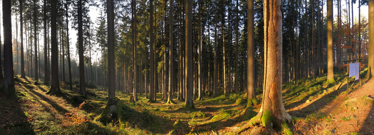

Various experimental parks provide land for different types of field trials. Major experiments are within the following subjects:

- Genetic diversity and breeding
- Regeneration and establishment
- Stand treatment, growth and yield
- Ecosystem, soil and water conditions
- Wood biomass for energy production
- Peat land forestry.

The research station is usually in cooperation with departments at SLU and other universities and research institutes in Sweden. Some of the data used for this analysis were provided mainly by this research station and have been [uploaded here](https://github.com/xrander/SLU-Plantation-Experimentation/tree/master/Data).

I will be taking us through the analysis journey. Terms relating to forestry will be explained, while syntax of R used won’t be explained.

**Tools and Packages Used** RStudio was mainly used for the analysis of the data. Libraries used were mainly doBy, lattice, ggplot, TukeyC, and Car. To install the package run the command like this `install.packages('package name')` as an example `install.packages('dplyr')`.

====NB: For most part of the visualization base-r and lattice library were used, ggplot was used at times====

*Loading the libraries*

```r
library(doBy)
library(dplyr)
```

```r
library(lattice)
library(ggplot2)
library(car)
library(data.table)
library(TukeyC)
```

# Experiments

Various experiments ranging from regeneration experiment to thinning experiment were carried out and date was analyzed to see the effect of various treatments (stand tending operations) at different stand development stage. The experiments are:

Fertilization of plantations in Sweden is area specific. In the Northern part of Sweden the use of fertilizer is common, while in the Southern region its use is prohibited. The Southern part is having rich soil and have no need to fertilize the soil. Swedish forest fertilization mainly involves the application of Nitrogen which is normally the limiting nutrient for high stand growth

This experiment is set to see the effect of fertilization frequency on the growth of a stand. The experiment is a young Norway Spruce stands which was established with 5 blocks having randomly distributed treatments in 0.1 ha plots. The treatments are with 3 different intensities in fertilization.

```
- F1: Fertilized every year

- F2:   Fertilized every second year

- F3:   Fertilized every third year

-  C:   Control without Fertilzation.
```

- **Cuttings Experiment**:

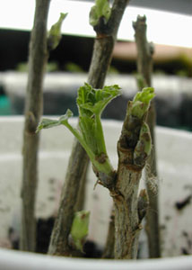

*source: Sustainable Gardening Australia*

Cuttings are one of the ways to propagate tree seedlings, another is through seeding. The later is the common in Sweden’s nursery. This experiment test the effect of fertilization on different clones of poplar cuttings.

- **Thinning Frequency and Intensity Experiment**: Basic data exploration and data visualization on a stand after being thinned giving insight on the influence of thinning frequency and/or intensity on some growth yield parameters.
- **Clone Trial Experiment**: Experiment to test the effect of fertilization on the performance of different clones.
- **Growth Experiment**: Estimation of some forestry growth parameters.
- **Spacing Experiment**: Experiment to test the effect of spacing density on the diameter and basal of a stand.
- **Thinning Experiment on Scots Pine**:

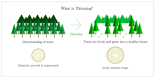

  An experiment to evaluate the effect of three different thinning regimes on the total volume produced in a stand.
- **Mixed Forest Experiment**: Volume estimation between pure monoculture and a mixed forest of 80:20 of monoculture and 50:50 of monoculture.
- **Site Preparation Experiment**: A site preparation experiment to evaluate the growth and survival of lodgepole pine under scarified and unscarified site.

[Portfolio Page](http://olamideadu.com)